# Exploring the MTPL1 Frequency Dataset

### 3.2.2 Multivariate Missing Data

It is useful to get an idea of what combinations of variables tend to have variables with missing values simultaneously, so to construct a visualisation for this we create a count of all the times given combinations of variables have missing values, producing a heat map for these combination counts.

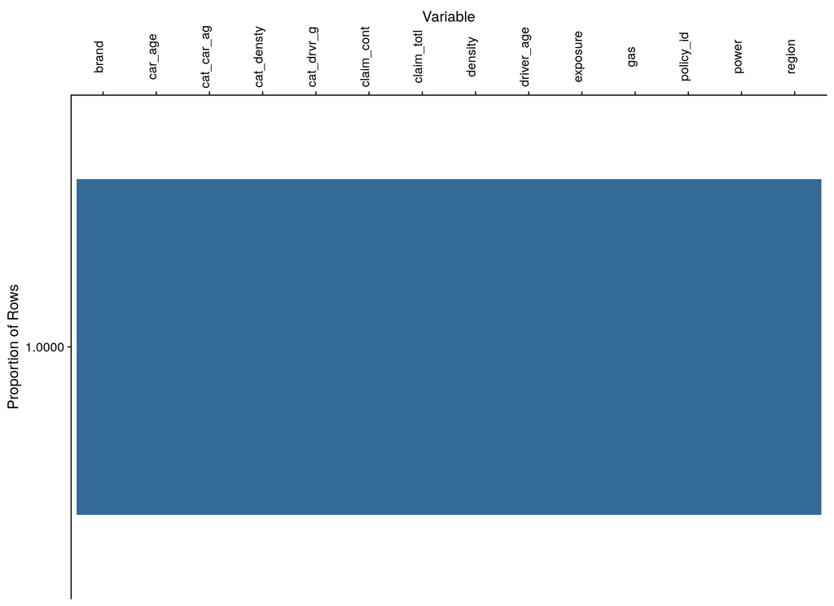

```r
dataexp_missing_group_count <- 20

row_count <- rawdata_tbl %>% nrow()

count_nas <- ~ .x %>% are_na() %>% vec_cast(integer())

missing_vizdata_tbl <- rawdata_tbl %>%
  mutate(across(everything(), count_nas)) %>%
  mutate(label = pmap_chr(., str_c)) %>%
  group_by(label) %>%
  mutate(
    miss_count = n(),
    miss_prop  = miss_count / row_count
    ) %>%
  slice_max(order_by = miss_prop, n = 1, with_ties = FALSE) %>%
  ungroup() %>%
  pivot_longer(
    !c(label, miss_count, miss_prop),
    names_to = "variable_name",
    values_to = "presence"
    ) %>%
  mutate(
    prop_label = sprintf("%6.4f", miss_prop)
    )

top10_data_tbl <- missing_vizdata_tbl %>%
  select(label, miss_prop) %>%
  distinct() %>%
  slice_max(order_by = miss_prop, n = dataexp_missing_group_count)

missing_plot_tbl <- missing_vizdata_tbl %>%
  semi_join(top10_data_tbl, by = "label")

ggplot(missing_plot_tbl) +
  geom_tile(aes(x = variable_name, y = prop_label, fill = presence), height = 0.8) +
  scale_fill_continuous() +
  scale_x_discrete(position = "top", labels = ~ abbreviate(.x, minlength = 10)) +
  xlab("Variable") +
  ylab("Proportion of Rows") +
  theme(
    legend.position = "none",
    axis.text.x = element_text(angle = 90, vjust = 0.5)
    )
```

This visualisation takes a little explaining.

## 3.3 Inspect High-level-count Categorical Variables

With the raw data loaded up we now remove obvious unique or near-unique variables that are not amenable to basic exploration and plotting.

```r
coltype_lst <- create_coltype_list(data_tbl)

count_levels <- ~ .x %>% unique() %>% length()

catvar_valuecount_tbl <- data_tbl %>%
  summarise(
    .groups = "drop",

    across(coltype_lst$split$discrete, count_levels)
    ) %>%
  pivot_longer(
    cols      = everything(),
    names_to  = "var_name",
    values_to = "level_count"
    ) %>%
  arrange(desc(level_count))

print(catvar_valuecount_tbl)
```

```
# A tibble: 8 × 2
  var_name       level_count
  <chr>                <int>
1 policy_id           413169
2 power                   12
3 region                  10
4 brand                    7
5 cat_driver_age           5
6 cat_density              5
7 cat_car_age              4
8 gas                      2
```

```r
row_count <- data_tbl %>% nrow()

cat(glue("Dataset has {row_count} rows\n"))
```

```
Dataset has 413169 rows
```

Now that we a table of the counts of all the categorical variables we can automatically exclude unique variables from the exploration, as the level count will match the row count.

```r
unique_vars <- catvar_valuecount_tbl %>%
  filter(level_count == row_count) %>%
  pull(var_name)

print(unique_vars)
```

```
[1] "policy_id"
```

```r
explore_data_tbl <- data_tbl %>%
  select(-one_of(unique_vars))
```

Having removed the unique identifier variables from the dataset, we may also wish to exclude categoricals with high level counts also, so we create a vector of those variable names.

```r
highcount_vars <- catvar_valuecount_tbl %>%
  filter(level_count >= dataexp_level_exclusion_threshold,
         level_count < row_count) %>%
  pull(var_name)

cat(str_c(highcount_vars, collapse = ", "))
```

We now can continue doing some basic exploration of the data. We may also choose to remove some extra columns from the dataset.

```r
### You may want to comment out these next few lines to customise which
### categoricals are kept in the exploration.
drop_vars <- c(highcount_vars)

if (length(drop_vars) > 0) {
  explore_data_tbl <- explore_data_tbl %>%
      select(-one_of(drop_vars))

  cat(str_c(drop_vars, collapse = ", "))
}
```

# 4 Univariate Data Exploration

Now that we have loaded the data we can prepare it for some basic data exploration.

## 4.1 Quick Univariate Data Summaries

We use a number of summary visualisations provided by `DataExplorer`: a facet plot across each variable with categorical variables getting bar plots and numerical plots getting histograms.

We first look at the barplots of categorical variables.

```
1 columns ignored with more than 50 categories.
policy_id: 413169 categories
```

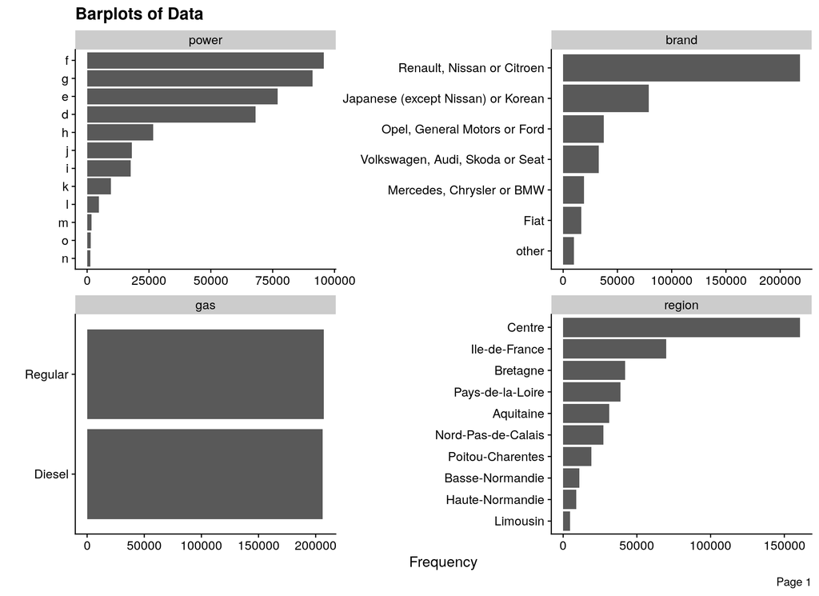

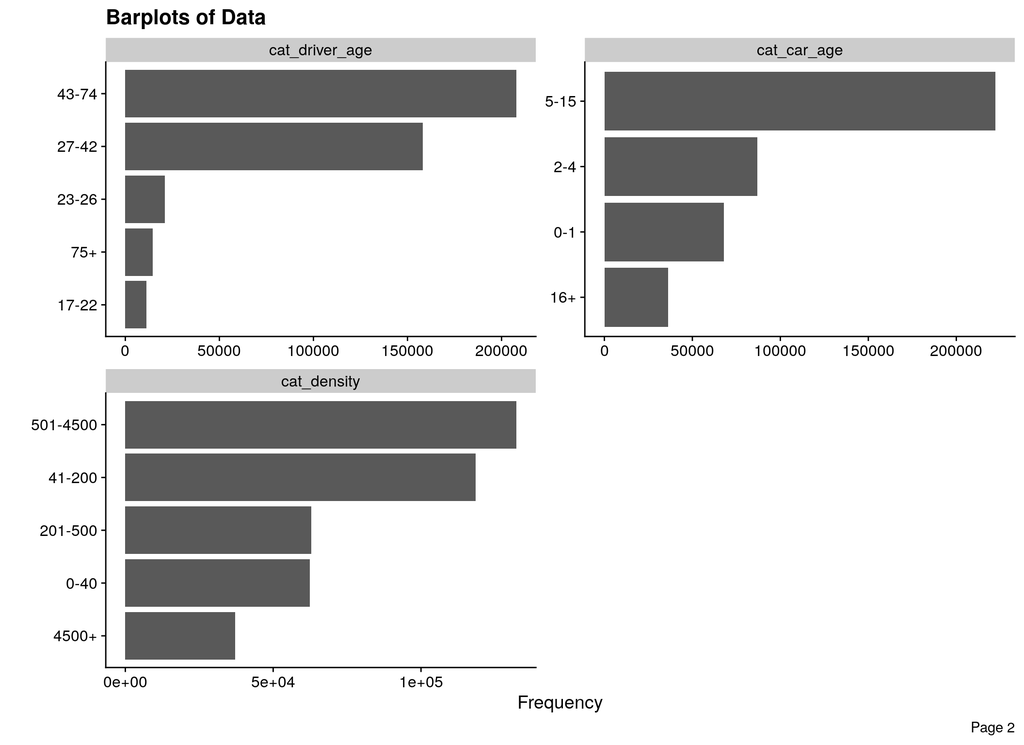

```r
plot_bar(
    data_tbl,
    ncol    = 2,
    nrow    = 2,
    title   = "Barplots of Data",
    ggtheme = theme_cowplot()
    )
```

We then have a quick look at histograms of the numeric variables.

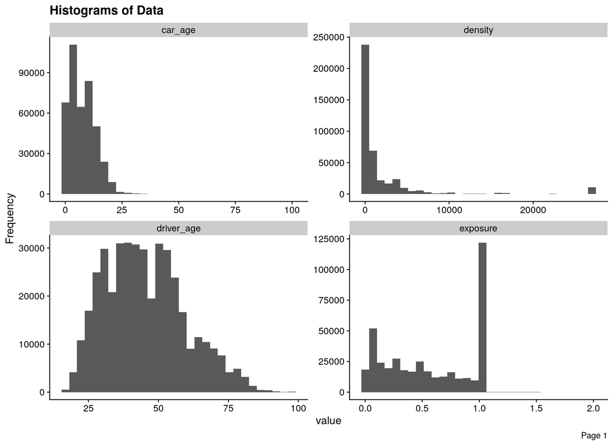

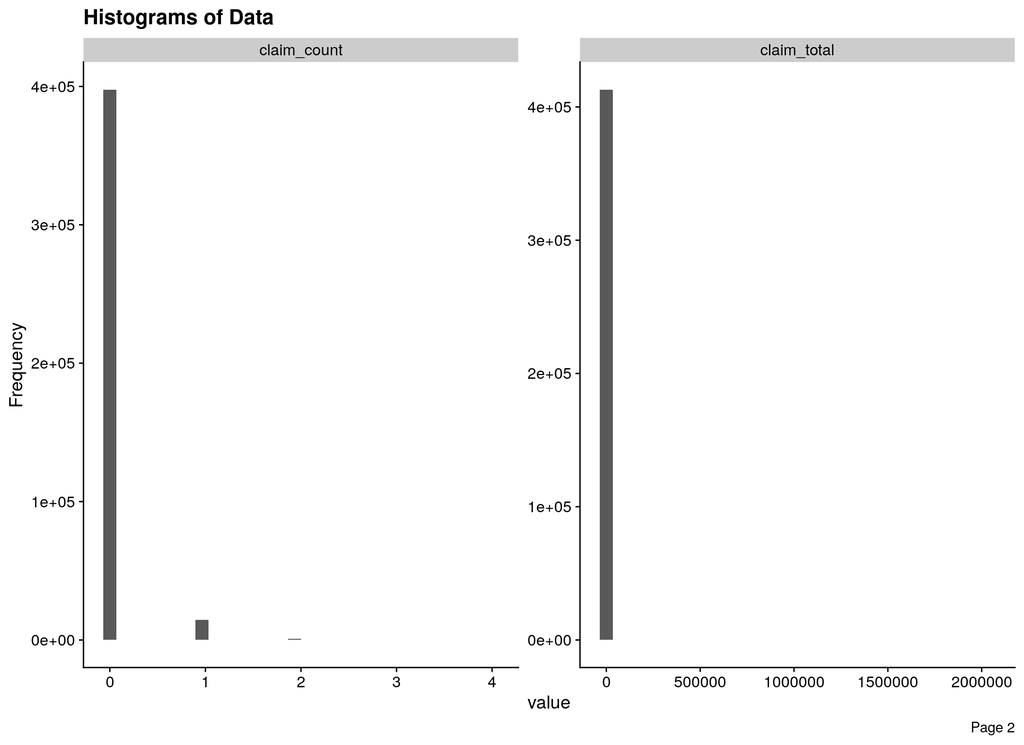

```r
plot_histogram(
    data_tbl,
    ncol    = 2,
    nrow    = 2,
    title   = "Histograms of Data",
    ggtheme = theme_cowplot()
    )
```

Finally, we split the remaining variables into different categories and then produce a sequence of plots for each variable.

```r
coltype_lst <- create_coltype_list(explore_data_tbl)

print(coltype_lst)
```

```
$split
$split$continuous
[1] "exposure"    "car_age"     "driver_age"  "density"     "claim_total"
[6] "claim_count"

$split$discrete
[1] "power"          "brand"          "gas"            "region"
[5] "cat_driver_age" "cat_car_age"    "cat_density"


$columns
      exposure          power        car_age     driver_age          brand
  "continuous"     "discrete"   "continuous"   "continuous"     "discrete"
           gas         region        density    claim_total    claim_count
    "discrete"     "discrete"   "continuous"   "continuous"   "continuous"
cat_driver_age    cat_car_age    cat_density
    "discrete"     "discrete"     "discrete"
```

## 4.2 Logical Variables

Logical variables only take two values: TRUE or FALSE. It is useful to see missing data as well though, so we also plot the count of those.

```r
logical_vars <- coltype_lst$split$logical %>% sort()

for (plot_varname in logical_vars) {
  cat("--\n")
  cat(glue("{plot_varname}\n"))

  na_count <- explore_data_tbl %>% pull(.data[[plot_varname]]) %>% are_na() %>% sum()

  plot_title <- glue("Barplot of Counts for Variable: {plot_varname} ({na_count} missing values)")

  explore_plot <- ggplot(explore_data_tbl) +
    geom_bar(aes(x = .data[[plot_varname]])) +
    xlab(plot_varname) +
    ylab("Count") +
    scale_y_continuous(labels = label_comma()) +
    ggtitle(plot_title) +
    theme(axis.text.x = element_text(angle = 30, vjust = 0.5))

  plot(explore_plot)
}
```

## 4.3 Numeric Variables

Numeric variables are usually continuous in nature, though we also have integer data.

```
--
car_age   Min. 1st Qu.  Median    Mean 3rd Qu.    Max.
  0.000   3.000   7.000   7.532  12.000 100.000
```

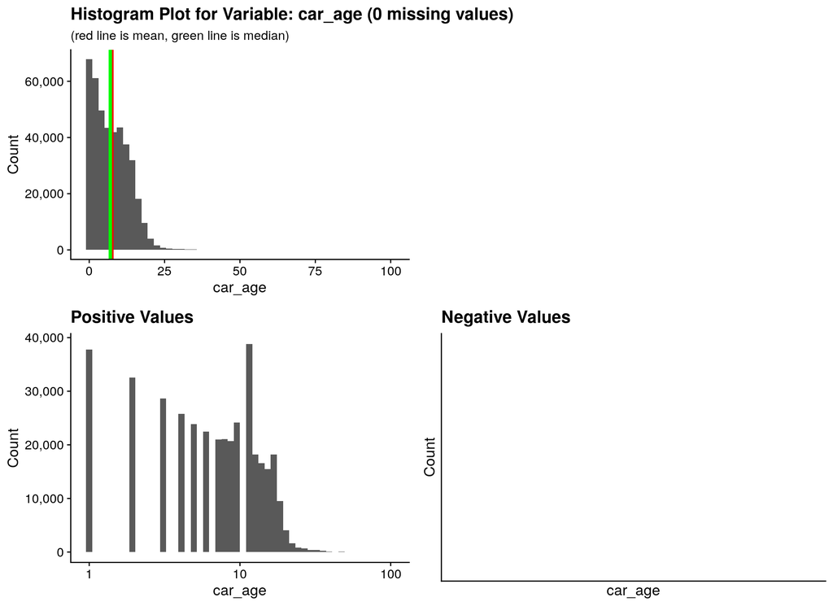

```
--
claim_count   Min. 1st Qu.  Median    Mean 3rd Qu.    Max.
0.00000 0.00000 0.00000 0.03916 0.00000 4.00000
```

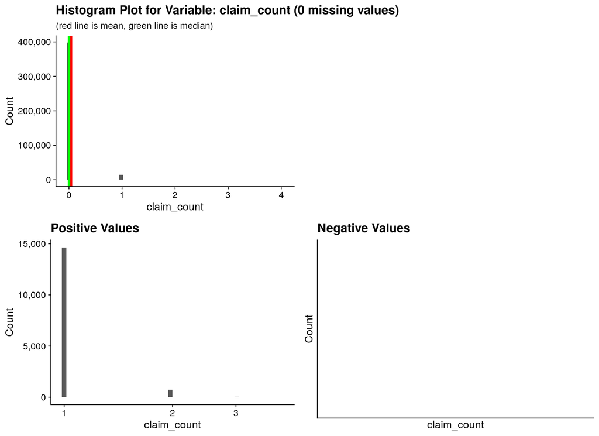

```
--
claim_total     Min.   1st Qu.    Median      Mean   3rd Qu.      Max.
      0.0       0.0       0.0      83.4       0.0 2036833.0
```

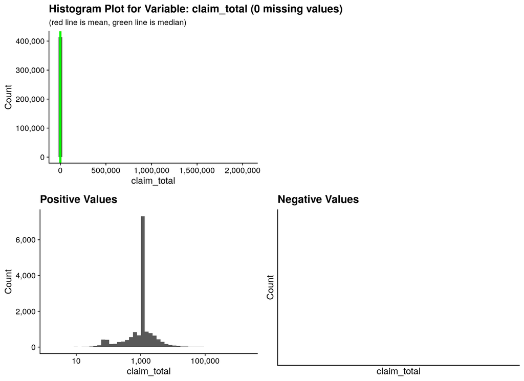

```
--
density   Min. 1st Qu.  Median    Mean 3rd Qu.    Max.
      2      67     287    1985    1410   27000
```

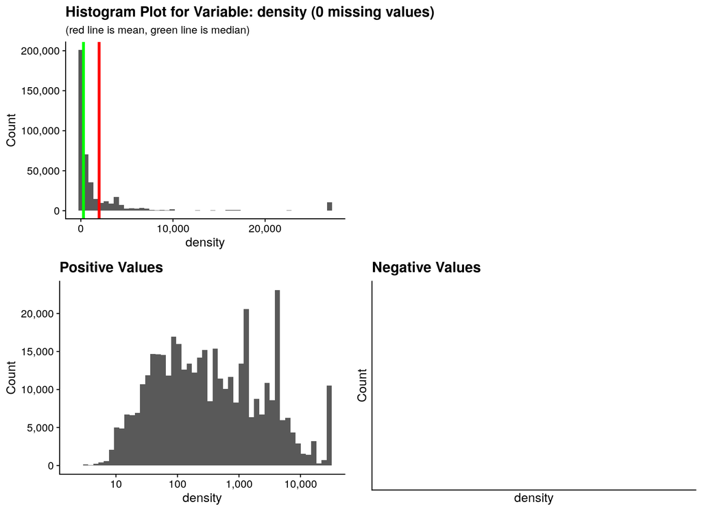

```
--
driver_age   Min. 1st Qu.  Median    Mean 3rd Qu.    Max.
  18.00   34.00   44.00   45.32   54.00   99.00
```

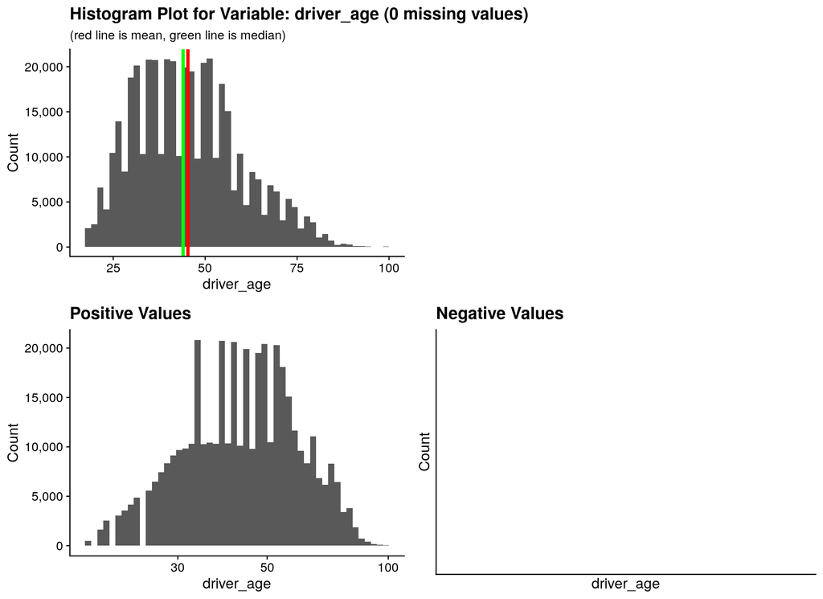

```
--
exposure    Min.  1st Qu.   Median     Mean  3rd Qu.     Max.
0.002732 0.200000 0.540000 0.561088 1.000000 1.990000
```

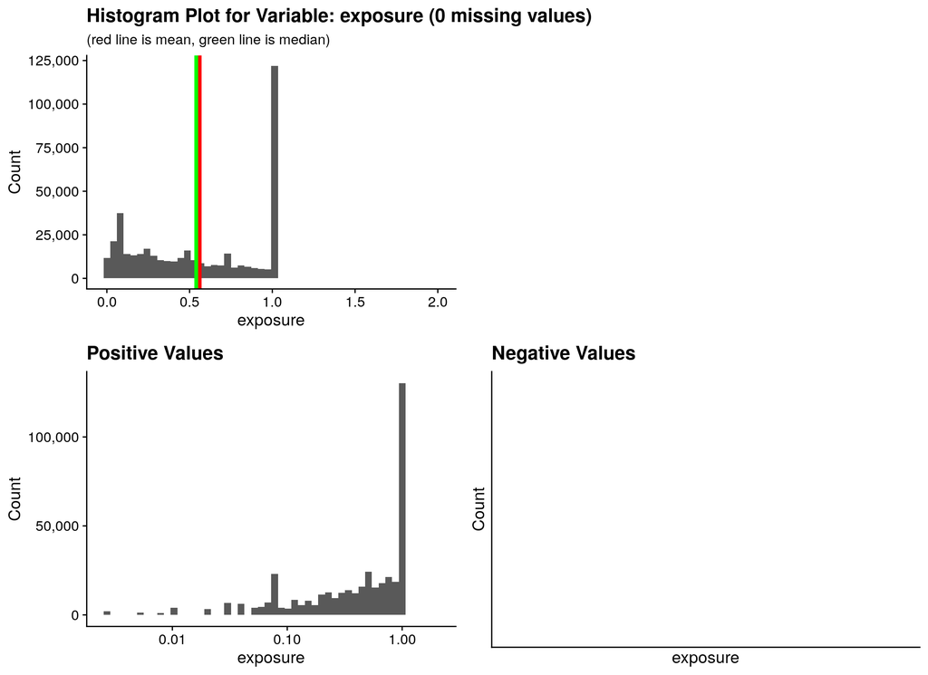

```r
numeric_vars <- coltype_lst$split$continuous %>% sort()

for (plot_varname in numeric_vars) {
  cat("--\n")
  cat(glue("{plot_varname}\n"))

  plot_var <- explore_data_tbl %>% pull(.data[[plot_varname]])
  na_count <- plot_var %>% are_na() %>% sum()

  plot_var %>% summary() %>% print()

  plot_title <- glue("Histogram Plot for Variable: {plot_varname} ({na_count} missing values)")


  all_plot <- ggplot() +
    geom_histogram(aes(x = plot_var), bins = dataexp_hist_bins_count) +
    geom_vline(xintercept = mean(plot_var, na.rm = TRUE),
               colour = "red", size = 1.5) +
    geom_vline(xintercept = median(plot_var, na.rm = TRUE),
               colour = "green", size = 1.5) +
    xlab(plot_varname) +
    ylab("Count") +
    scale_x_continuous(labels = label_comma()) +
    scale_y_continuous(labels = label_comma()) +
    ggtitle(
      plot_title,
      subtitle = "(red line is mean, green line is median)"
      )

  pos_data_tbl <- explore_data_tbl %>%
    filter(.data[[plot_varname]] >= 0) %>%
    mutate(var_val = abs(.data[[plot_varname]]))

  pos_log_plot <- ggplot(pos_data_tbl) +
    geom_histogram(aes(x = var_val), bins = dataexp_hist_bins_count) +
    xlab(plot_varname) +
    ylab("Count") +
    scale_x_log10(labels = label_comma()) +
    scale_y_continuous(labels = label_comma()) +
    ggtitle("Positive Values")


  neg_data_tbl <- explore_data_tbl %>%
    filter(.data[[plot_varname]] < 0) %>%
    mutate(var_val = abs(.data[[plot_varname]]))

  neg_log_plot <- ggplot(neg_data_tbl) +
    geom_histogram(aes(x = var_val), bins = dataexp_hist_bins_count) +
    xlab(plot_varname) +
    ylab("Count") +
    scale_x_log10(labels = label_comma()) +
    scale_y_continuous(labels = label_comma()) +
    ggtitle("Negative Values")


  plot_grid(
      all_plot,
      NULL,
      pos_log_plot,
      neg_log_plot,
      nrow = 2
      ) %>%
    print()
}
```

## 4.4 Categorical Variables

Categorical variables only have values from a limited, and usually fixed, number of possible values

```
--
brand
```

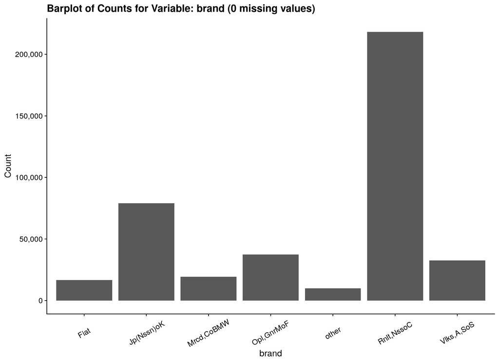

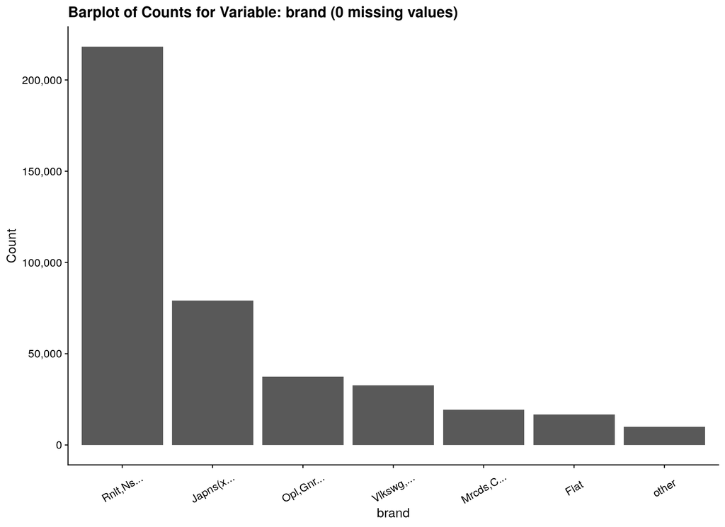

```
--
cat_car_age
```

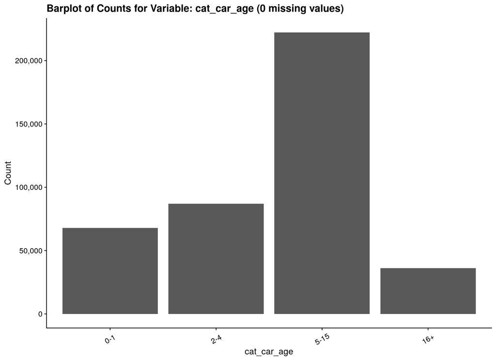

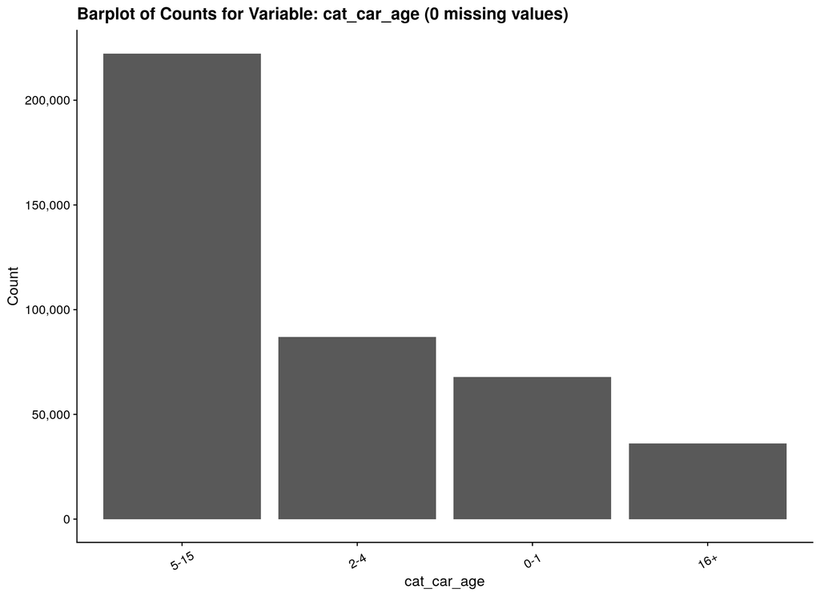

```
--
cat_density
```

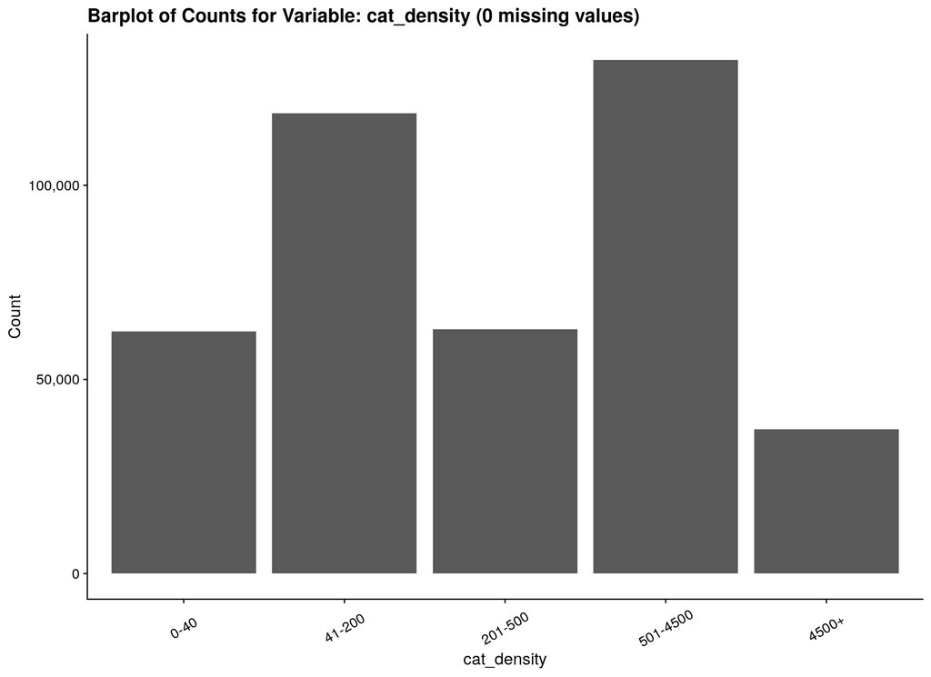

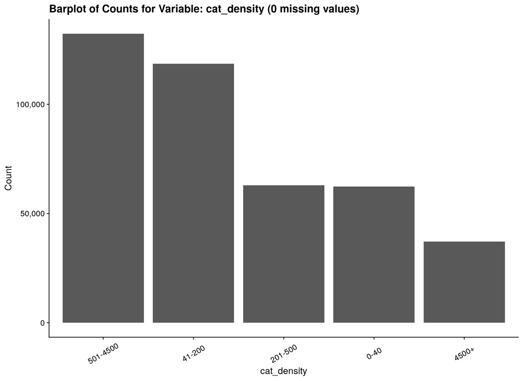

```
--
cat_driver_age
```

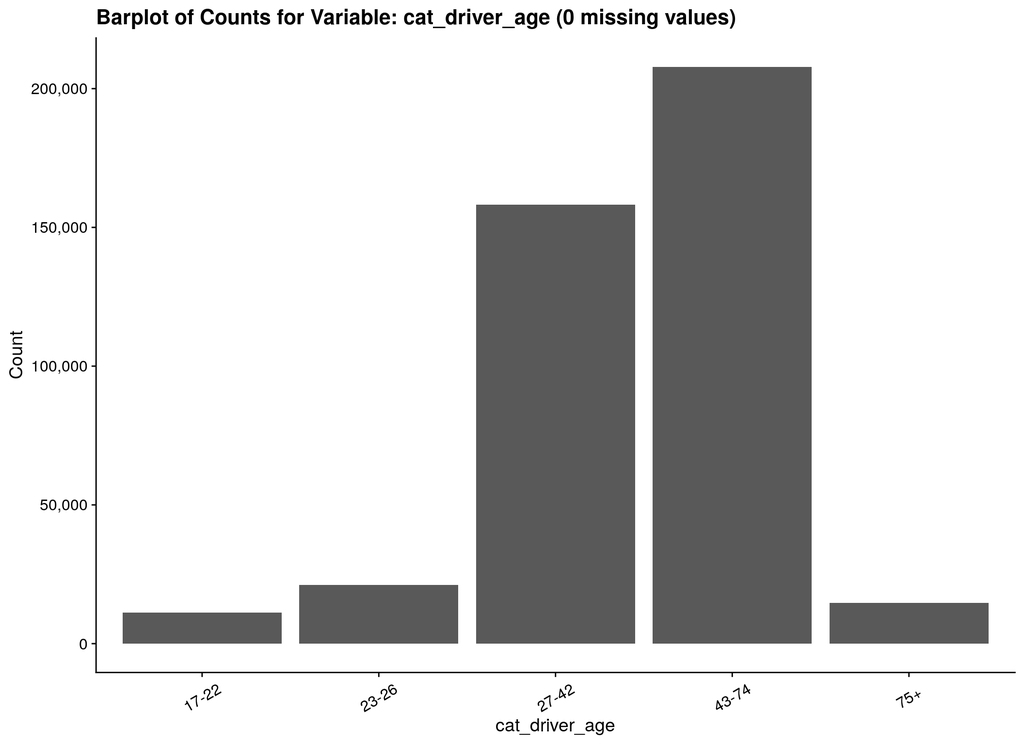

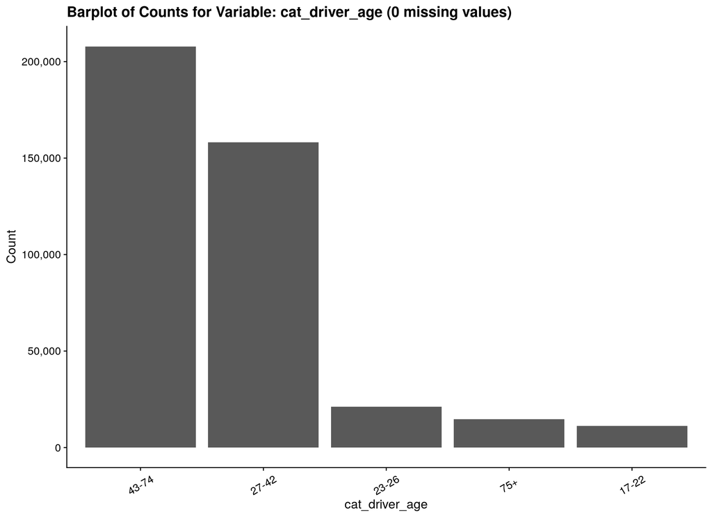

```
--
gas
```

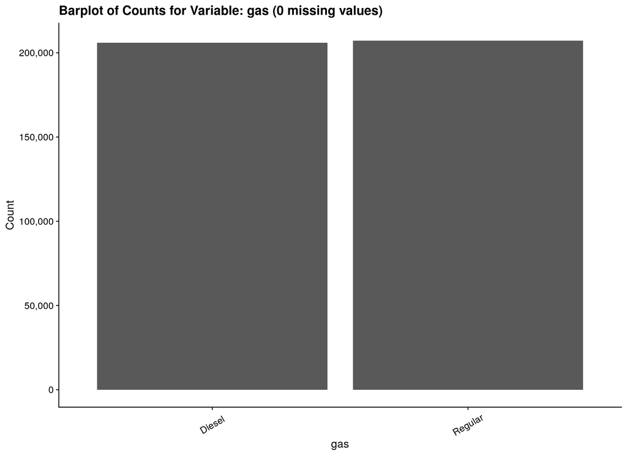

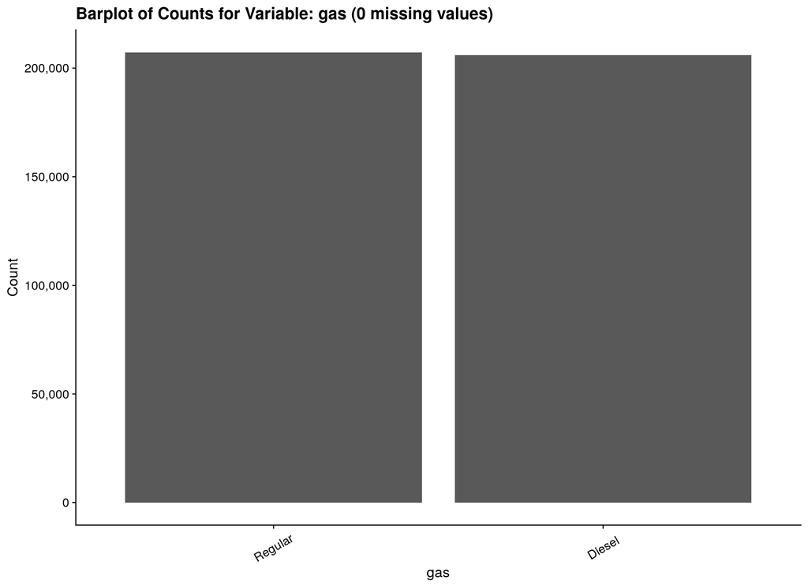

```
--
power
```

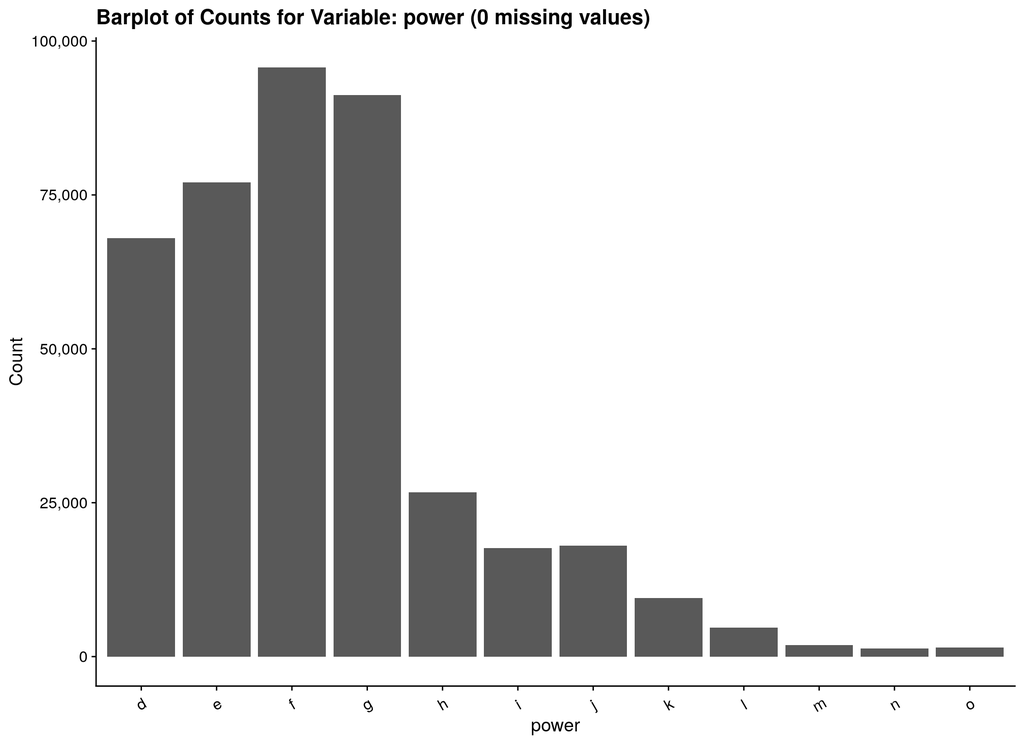

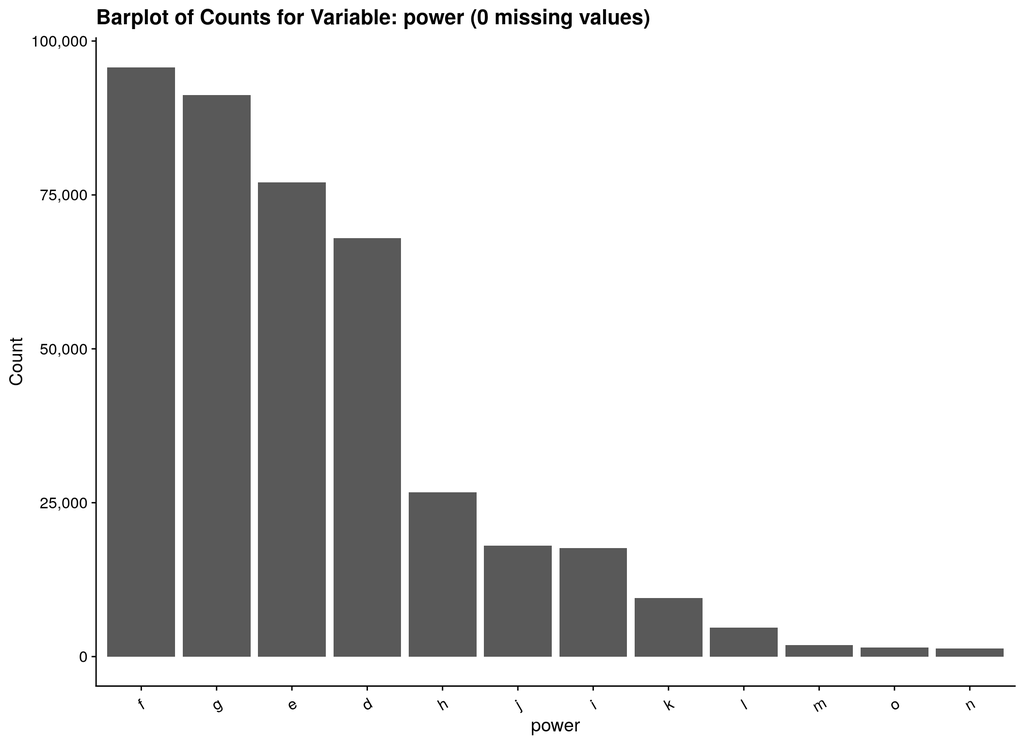

```
--
region
```

[2 more figures not shown]

```r
categorical_vars <- coltype_lst$split$discrete %>% sort()

for (plot_varname in categorical_vars) {
  cat("--\n")
  cat(glue("{plot_varname}\n"))

  na_count <- explore_data_tbl %>% pull(.data[[plot_varname]]) %>% are_na() %>% sum()

  plot_title <- glue("Barplot of Counts for Variable: {plot_varname} ({na_count} missing values)")

  standard_plot_tbl <- explore_data_tbl %>%
    count(.data[[plot_varname]])

  standard_plot <- ggplot(standard_plot_tbl) +
    geom_bar(aes(x = .data[[plot_varname]], weight = n)) +
    xlab(plot_varname) +
    ylab("Count") +
    scale_x_discrete(labels = ~ abbreviate(.x, minlength = 10)) +
    scale_y_continuous(labels = label_comma()) +
    ggtitle(plot_title) +
    theme(axis.text.x = element_text(angle = 30, vjust = 0.5))

  standard_plot %>% print()


  desc_plot_tbl <- explore_data_tbl %>%
    pull(.data[[plot_varname]]) %>%
    fct_lump(n = dataexp_cat_level_count) %>%
    fct_count() %>%
    mutate(f = fct_relabel(f, str_trunc, width = 15))

  desc_plot <- ggplot(desc_plot_tbl) +
    geom_bar(aes(x = fct_reorder(f, -n), weight = n)) +
    xlab(plot_varname) +
    ylab("Count") +
    scale_x_discrete(labels = ~ abbreviate(.x, minlength = 10)) +
    scale_y_continuous(labels = label_comma()) +
    ggtitle(plot_title) +
    theme(axis.text.x = element_text(angle = 30, vjust = 0.5))

  desc_plot %>% print()
}
```

## 4.5 Date/Time Variables

Date/Time variables represent calendar or time-based data should as time of the day, a date, or a timestamp.

```r
datetime_vars <- coltype_lst$split$datetime %>% sort()

for (plot_varname in datetime_vars) {
  cat("--\n")
  cat(glue("{plot_varname}\n"))

  plot_var <- explore_data_tbl %>% pull(.data[[plot_varname]])
  na_count <- plot_var %>% are_na() %>% sum()

  plot_var %>% summary() %>% print()

  plot_title <- glue("Barplot of Dates/Times in Variable: {plot_varname} ({na_count} missing values)")


  explore_plot <- ggplot(explore_data_tbl) +
    geom_histogram(aes(x = .data[[plot_varname]]), bins = dataexp_hist_bins_count) +
    xlab(plot_varname) +
    ylab("Count") +
    scale_y_continuous(labels = label_comma()) +
    ggtitle(plot_title)

  plot(explore_plot)
}
```